# Rus- og tobakksundersøkelsen 2026

Autogenerated data summary from dataReporter

2026-11-17 13:28:15.396974

# Data report overview

The dataset examined has the following dimensions:

| Feature | Result |
| --- | --- |
| Number of observations | 4672 |
| Number of variables | 318 |

### Checks performed

The following variable checks were performed, depending on the data type of each variable:

|  | character | factor | labelled | haven labelled | numeric | integer | logical | Date |
| --- | --- | --- | --- | --- | --- | --- | --- | --- |
| Identify miscoded missing values | × | × | × | × | × | × |  | × |
| Identify prefixed and suffixed whitespace | × | × | × | × |  |  |  |  |
| Identify levels with < 6 obs. | × | × | × | × |  |  |  |  |
| Identify case issues | × | × | × | × |  |  |  |  |
| Identify misclassified numeric or integer variables | × | × | × | × |  |  |  |  |
| Identify outliers |  |  |  |  | × | × |  | × |

Please note that all numerical values in the following have been rounded to 2 decimals.

# Codebook summary table

| Label | Variable | Class | # unique values | Missing | Description |
| --- | --- | --- | --- | --- | --- |
| Tettbygd spredtbygd | **ts_kode** | haven_labelled | 3 | 0.02 % |  |
| Sivilstand | **sivilstand** | haven_labelled | 10 | 0.02 % |  |
| Kjønn | **kjonn** | haven_labelled | 2 | 0.00 % |  |
| Alder | **alder** | character | 64 | 0.00 % |  |
| Kommunesentralitet | **sentralitet** | haven_labelled | 6 | 0.00 % |  |
| Alder gruppert | **aldersgruppe** | haven_labelled | 4 | 0.00 % |  |
| Fylke | **fylke** | haven_labelled | 15 | 0.00 % |  |
| Landsdel | **landsdel** | haven_labelled | 6 | 0.00 % |  |
| Statsborgerskap gruppert | **statsborgerskap_gruppert** | haven_labelled | 8 | 0.02 % |  |
| Fødeland gruppert | **fodeland_gruppert** | haven_labelled | 8 | 0.02 % |  |
| Mors fodeland gruppert | **mors_fodeland_gruppert** | haven_labelled | 8 | 42.98 % |  |
| Fars fodeland gruppert | **fars_fodeland_gruppert** | haven_labelled | 8 | 50.90 % |  |
| Bruttoinntekt person gruppert | **samlet_inntekt_gruppert** | haven_labelled | 19 | 0.79 % |  |
| Bruttoinntekt husholdning gruppert | **hush_samlet_inntekt_gruppert** | haven_labelled | 24 | 0.71 % |  |
| Husholdningens inntekt etter skatt per forbruksenhet, EU-ekvivalensskala, gruppert | **hush_ies_eu_gruppert** | haven_labelled | 14 | 0.79 % |  |
| Utdanningsnivå | **utdanning** | haven_labelled | 11 | 0.79 % |  |
| Fagfelt | **fagfelt** | haven_labelled | 11 | 0.79 % |  |
| Yrke sammenslått fra register og koding | **yrkeskode_samlet** | haven_labelled | 11 | 2.65 % |  |
| Vekt | **vekt** | numeric | 266 | 0.00 % |  |
|  | **what** | haven_labelled | 2 | 0.00 % |  |
| Layout | **skjermtype** | character | 3 | 0.00 % |  |
| Yrkesaktiv? | **yrkesstatus** | haven_labelled | 4 | 0.00 % |  |
| Yrkesstatus?. | **yrkstat2** | haven_labelled | 11 | 68.00 % |  |
| Er du gift eller samboer? | **siv** | haven_labelled | 5 | 0.00 % |  |
| IOs formelle sivilstatus | **sivstat** | haven_labelled | 7 | 42.70 % |  |
| Antall medlemmer i husholdningen? | **antpers** | numeric | 13 | 0.00 % |  |
| Antall barn under 6 år. | **antbarn1** | numeric | 8 | 24.29 % |  |
| Antall barn 6-18 år. | **antbarn2** | numeric | 10 | 24.29 % |  |
| Egenopplevd helse. | **helse** | haven_labelled | 7 | 0.00 % |  |
| Hender at røyker | **tob1** | haven_labelled | 4 | 0.00 % |  |

[output cut: 288 more lines]

# Variable list

## ts_kode

*Tettbygd spredtbygd*

| Feature | Result |
| --- | --- |
| Variable type | haven_labelled |
| Number of missing obs. | 1 (0.02 %) |
| Number of unique values | 2 |
| Mode | “Tettbygd” |

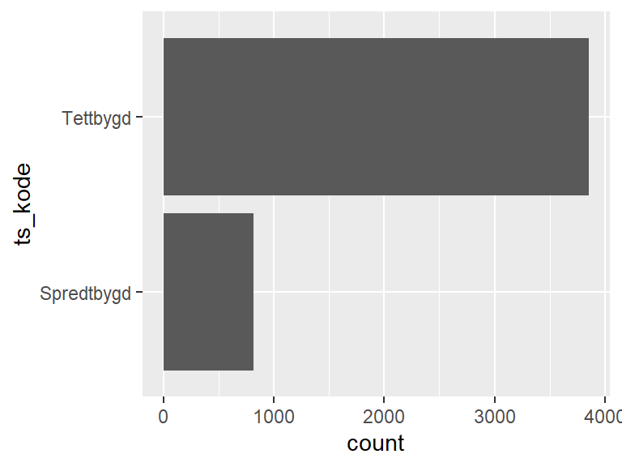

## sivilstand

*Sivilstand*

| Feature | Result |
| --- | --- |
| Variable type | haven_labelled |
| Number of missing obs. | 1 (0.02 %) |
| Number of unique values | 9 |
| Mode | “Ugift” |

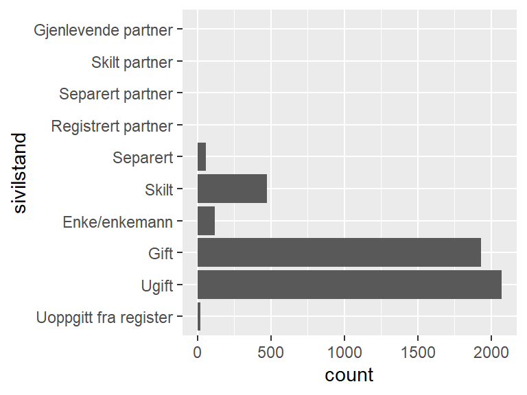

- Note that the following levels have at most five observations: "Gjenlevende partner", "Separert partner", "Skilt partner".

## kjonn

*Kjønn*

| Feature | Result |
| --- | --- |
| Variable type | haven_labelled |
| Number of missing obs. | 0 (0 %) |
| Number of unique values | 2 |
| Mode | “Kvinne” |

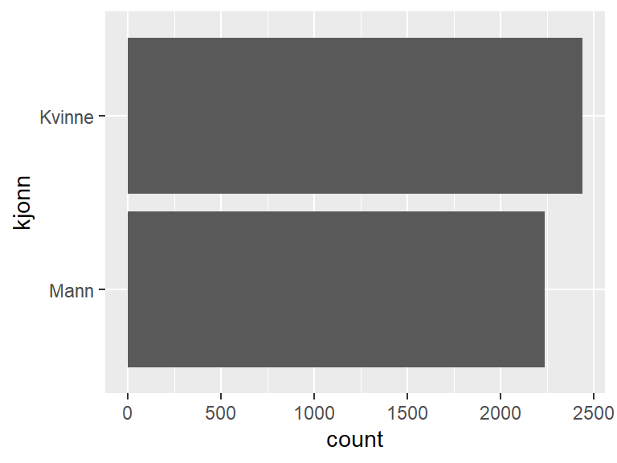

## alder

*Alder*

| Feature | Result |
| --- | --- |
| Variable type | character |
| Number of missing obs. | 0 (0 %) |
| Number of unique values | 64 |
| Mode | “59” |

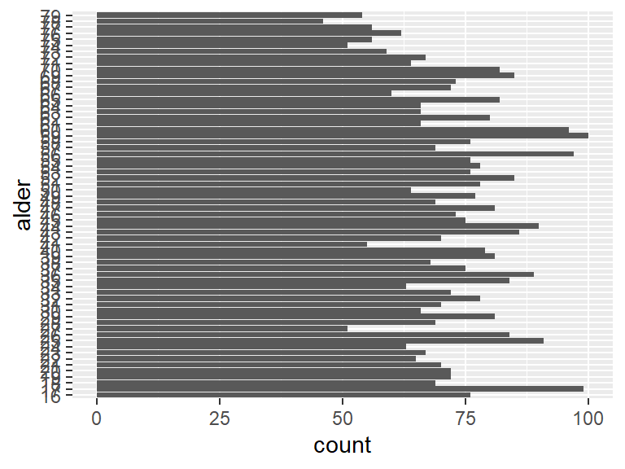

- Note: The variable consists exclusively of numbers and takes a lot of different values. Is it perhaps a misclassified numeric variable?

## sentralitet

*Kommunesentralitet*

| Feature | Result |
| --- | --- |
| Variable type | haven_labelled |
| Number of missing obs. | 0 (0 %) |
| Number of unique values | 6 |
| Mode | “2 (870-924)” |

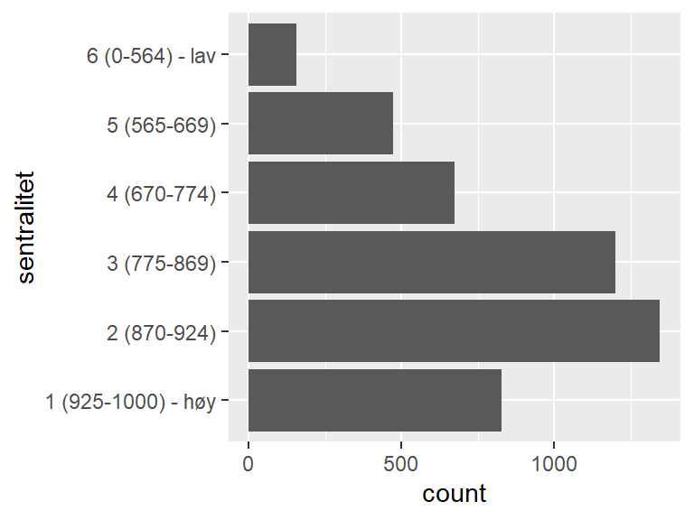

## aldersgruppe

*Alder gruppert*

| Feature | Result |
| --- | --- |
| Variable type | haven_labelled |
| Number of missing obs. | 0 (0 %) |
| Number of unique values | 4 |
| Mode | “45 - 66 år” |

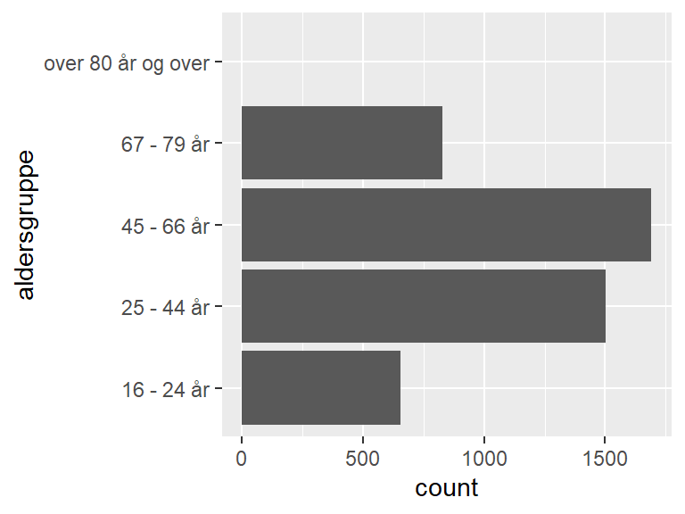

## fylke

*Fylke*

| Feature | Result |
| --- | --- |
| Variable type | haven_labelled |
| Number of missing obs. | 0 (0 %) |
| Number of unique values | 15 |
| Mode | “Akershus” |

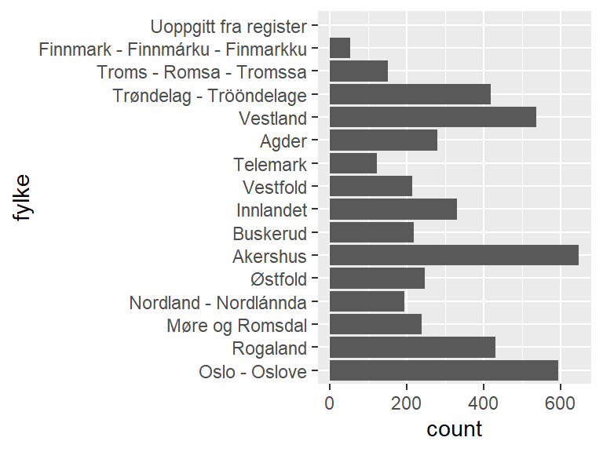

- Note: The variable consists exclusively of numbers and takes a lot of different values. Is it perhaps a misclassified numeric variable?

## landsdel

*Landsdel*

| Feature | Result |
| --- | --- |
| Variable type | haven_labelled |
| Number of missing obs. | 0 (0 %) |
| Number of unique values | 6 |
| Mode | “Akershus og Oslo” |

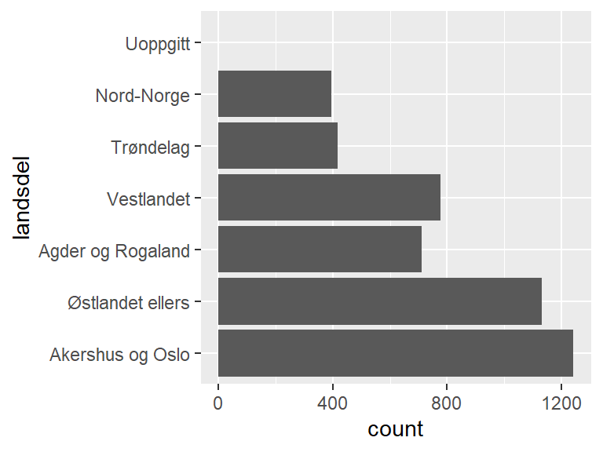

## statsborgerskap_gruppert

*Statsborgerskap gruppert*

| Feature | Result |
| --- | --- |
| Variable type | haven_labelled |
| Number of missing obs. | 1 (0.02 %) |
| Number of unique values | 7 |
| Mode | “Norge” |

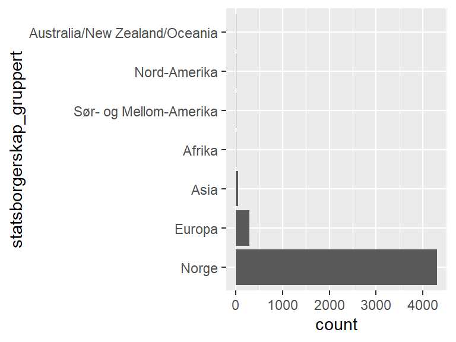

- Note that the following levels have at most five observations: "Australia/New Zealand/Oceania".

## fodeland_gruppert

*Fødeland gruppert*

| Feature | Result |
| --- | --- |
| Variable type | haven_labelled |
| Number of missing obs. | 1 (0.02 %) |
| Number of unique values | 7 |
| Mode | “Norge” |

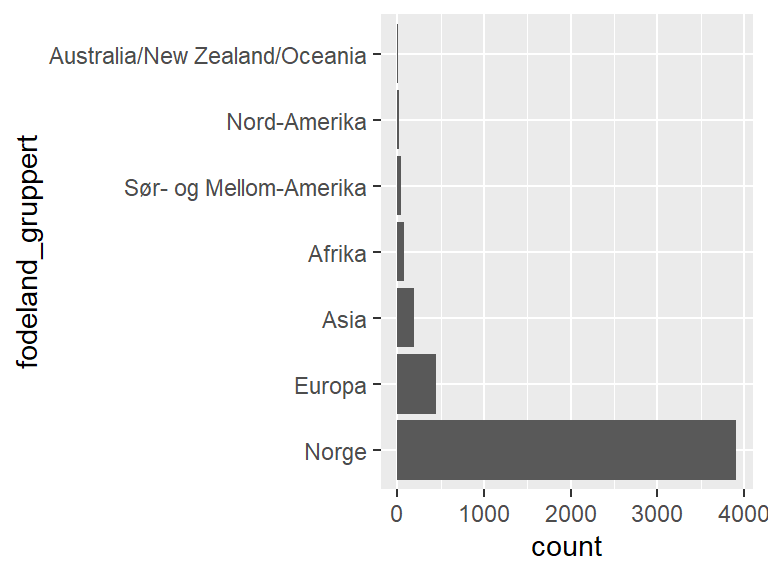

- Note that the following levels have at most five observations: "Australia/New Zealand/Oceania".

## mors_fodeland_gruppert

*Mors fodeland gruppert*

| Feature | Result |
| --- | --- |
| Variable type | haven_labelled |
| Number of missing obs. | 2008 (42.98 %) |
| Number of unique values | 7 |
| Mode | “Norge” |

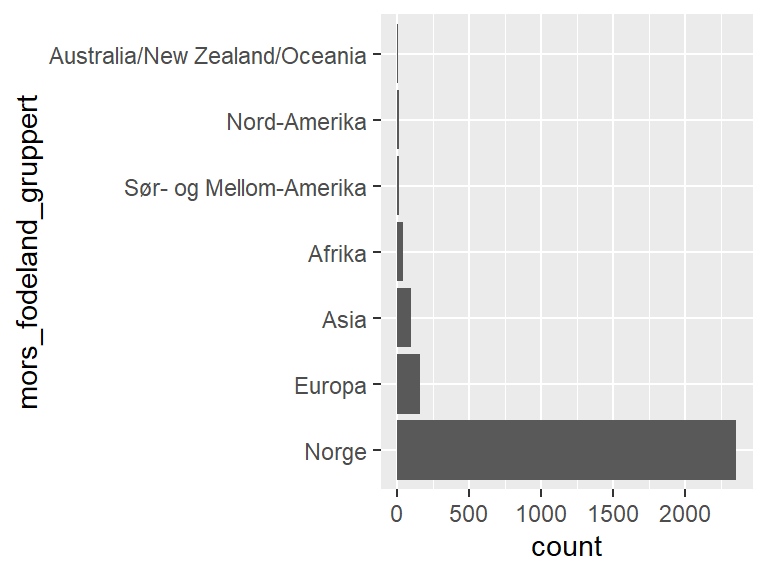

- Note that the following levels have at most five observations: "Australia/New Zealand/Oceania".

## fars_fodeland_gruppert

*Fars fodeland gruppert*

| Feature | Result |
| --- | --- |
| Variable type | haven_labelled |
| Number of missing obs. | 2378 (50.9 %) |
| Number of unique values | 7 |
| Mode | “Norge” |

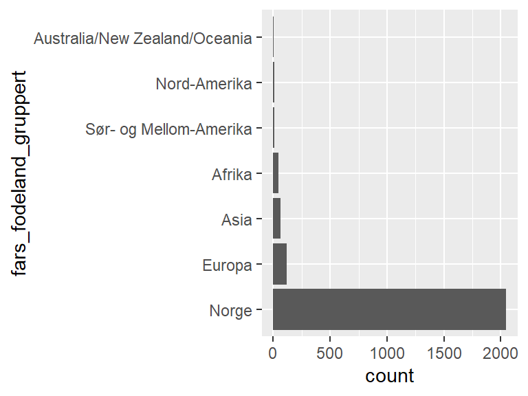

- Note that the following levels have at most five observations: "Australia/New Zealand/Oceania".

## samlet_inntekt_gruppert

*Bruttoinntekt person gruppert*

| Feature | Result |
| --- | --- |
| Variable type | haven_labelled |
| Number of missing obs. | 37 (0.79 %) |
| Number of unique values | 18 |
| Mode | “600 000 - 699 999” |

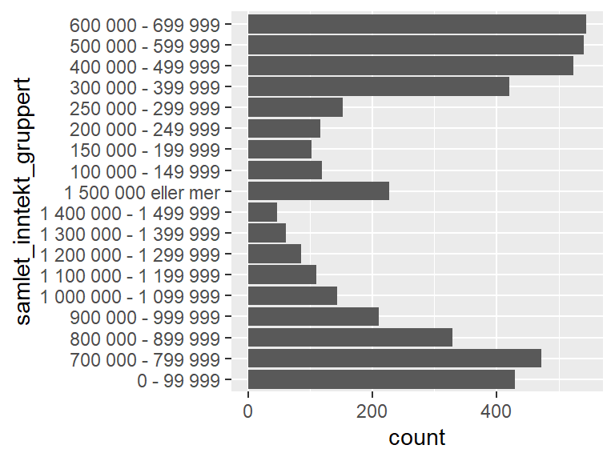

- Note: The variable consists exclusively of numbers and takes a lot of different values. Is it perhaps a misclassified numeric variable?

## hush_samlet_inntekt_gruppert

*Bruttoinntekt husholdning gruppert*

| Feature | Result |
| --- | --- |
| Variable type | haven_labelled |
| Number of missing obs. | 33 (0.71 %) |
| Number of unique values | 23 |
| Mode | “2 000 000 og mer” |

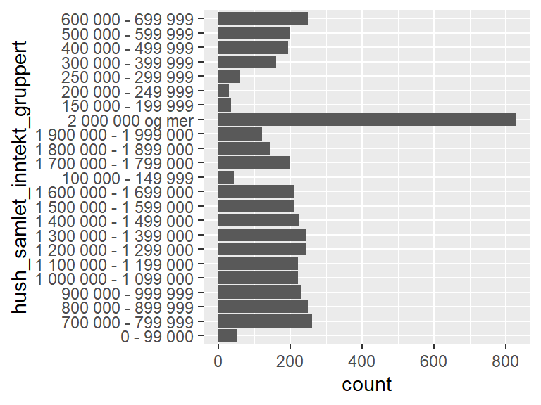

- Note: The variable consists exclusively of numbers and takes a lot of different values. Is it perhaps a misclassified numeric variable?

## hush_ies_eu_gruppert

*Husholdningens inntekt etter skatt per forbruksenhet, EU-ekvivalensskala, gruppert*

| Feature | Result |
| --- | --- |
| Variable type | haven_labelled |
| Number of missing obs. | 37 (0.79 %) |
| Number of unique values | 13 |
| Mode | “500 000 - 599 999” |

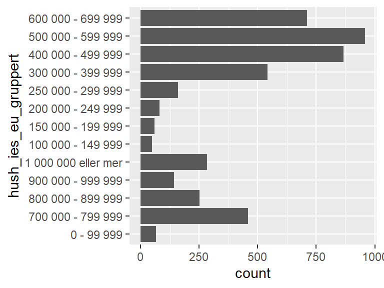

- Note: The variable consists exclusively of numbers and takes a lot of different values. Is it perhaps a misclassified numeric variable?

## utdanning

*Utdanningsnivå*

| Feature | Result |
| --- | --- |
| Variable type | haven_labelled |
| Number of missing obs. | 37 (0.79 %) |
| Number of unique values | 10 |
| Mode | “Universitets- og høgskoleutdanning, lavere nivå” |

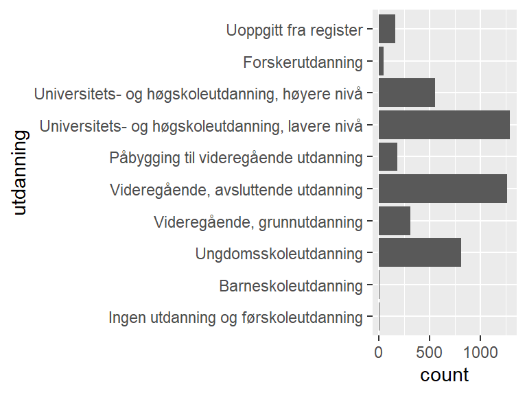

- Note that the following levels have at most five observations: "Ingen utdanning og førskoleutdanning".

## fagfelt

*Fagfelt*

| Feature | Result |
| --- | --- |
| Variable type | haven_labelled |
| Number of missing obs. | 37 (0.79 %) |
| Number of unique values | 10 |
| Mode | “Allmenne fag” |

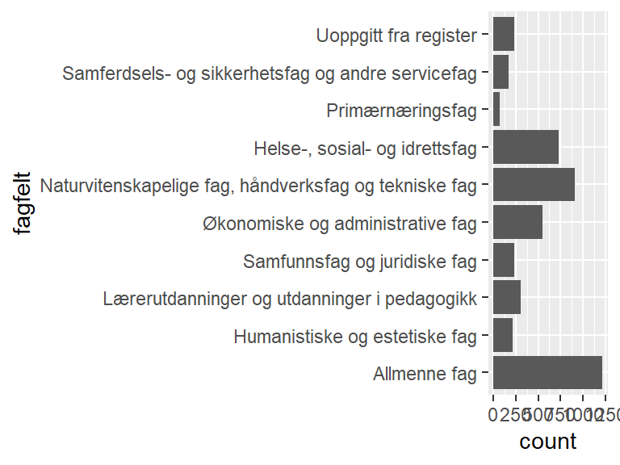

## yrkeskode_samlet

*Yrke sammenslått fra register og koding*

| Feature | Result |
| --- | --- |
| Variable type | haven_labelled |
| Number of missing obs. | 124 (2.65 %) |
| Number of unique values | 10 |
| Mode | “” |

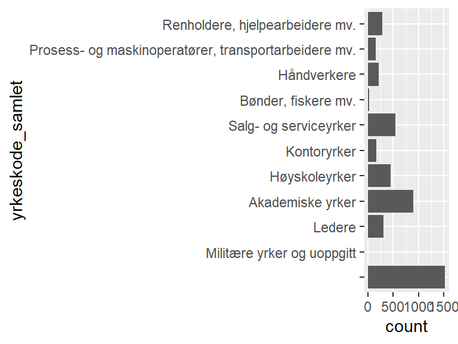

- The following suspected missing value codes enter as regular values: "".

## vekt

*Vekt*

| Feature | Result |
| --- | --- |
| Variable type | numeric |
| Number of missing obs. | 0 (0 %) |
| Number of unique values | 266 |
| Median | 912.82 |
| 1st and 3rd quartiles | 811.25; 1029.16 |
| Min. and max. | 587.33; 1712.99 |

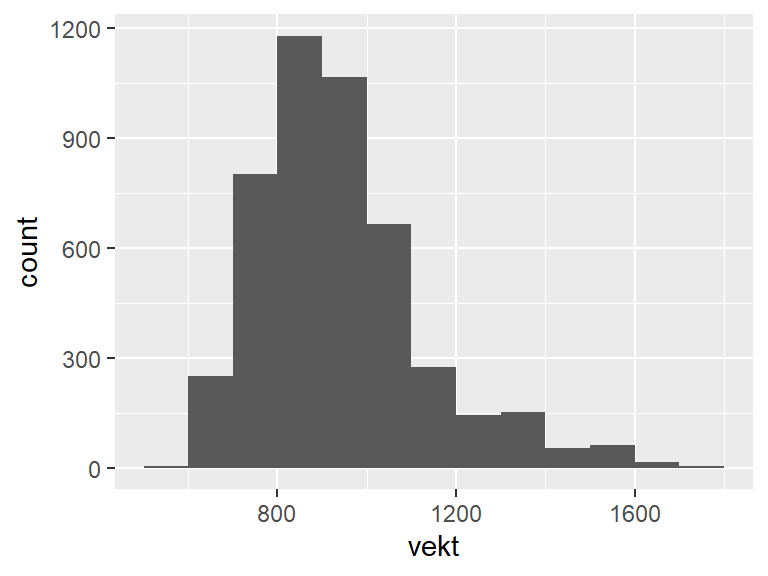

- Note that the following possible outlier values were detected: "1410.69", "1414.13", "1421.15", "1432.66", "1449.83", "1456.98", "1473.64", "1495.9", "1496.42", "1499.13", "1506.07", "1513.08", "1521.39", "1528.33", "1538.57", "1544.86", "1545.51", "1545.57", "1549.5", "1550.2", "1552.98", "1562.04", "1575.24", "1575.69", "1579.87", "1582.63", "1592.42", "1594.54", "1599.16", "1624.91", "1629.54", "1636.43", "1658.68", "1663.32", "1675.86", "1708.36", "1712.99".

## what

| Feature | Result |
| --- | --- |
| Variable type | haven_labelled |
| Number of missing obs. | 0 (0 %) |
| Number of unique values | 2 |
| Mode | “Bokmål” |

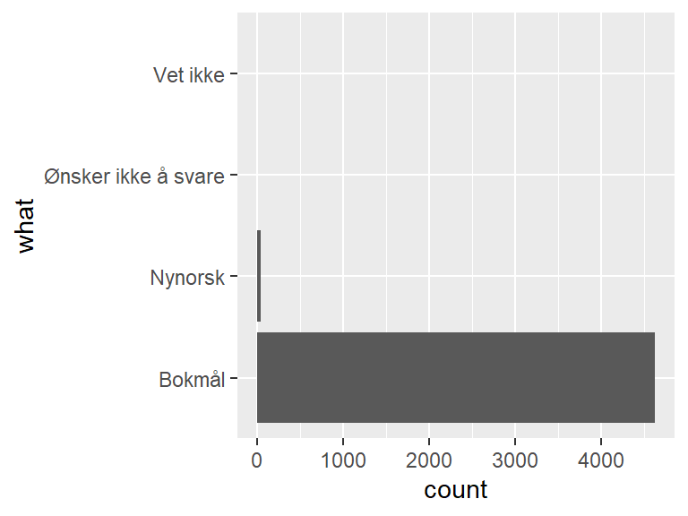

## skjermtype

*Layout*

| Feature | Result |
| --- | --- |
| Variable type | character |
| Number of missing obs. | 0 (0 %) |
| Number of unique values | 3 |
| Mode | “CASI-SSB_Small_Touch” |

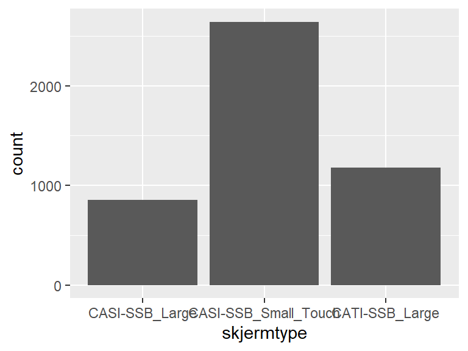

## yrkesstatus

*Yrkesaktiv?*

| Feature | Result |
| --- | --- |
| Variable type | haven_labelled |
| Number of missing obs. | 0 (0 %) |
| Number of unique values | 4 |
| Mode | “Ja” |

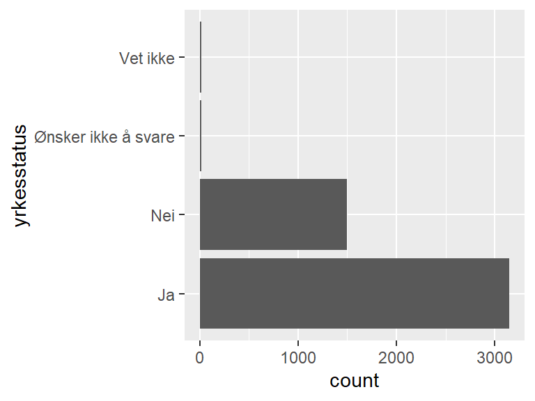

## yrkstat2

*Yrkesstatus?.*

| Feature | Result |
| --- | --- |
| Variable type | haven_labelled |
| Number of missing obs. | 3177 (68 %) |
| Number of unique values | 10 |
| Mode | “alders- eller førtidspensjonist” |

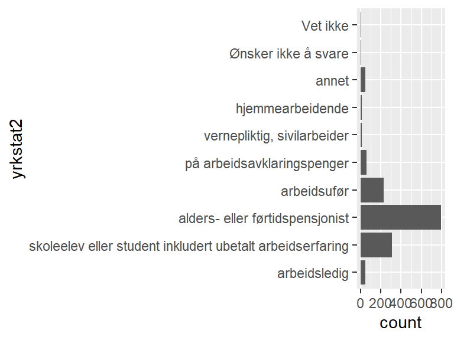

- Note that the following levels have at most five observations: "Vet ikke", "Ønsker ikke å svare".

## siv

*Er du gift eller samboer?*

| Feature | Result |
| --- | --- |
| Variable type | haven_labelled |
| Number of missing obs. | 0 (0 %) |
| Number of unique values | 5 |
| Mode | “Ja, gift/registrert partner” |

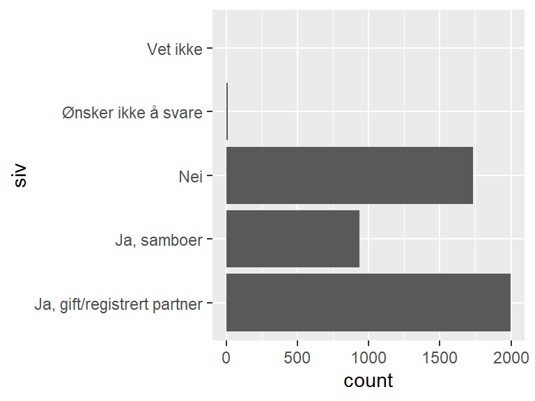

- Note that the following levels have at most five observations: "Vet ikke".

## sivstat

*IOs formelle sivilstatus*

| Feature | Result |
| --- | --- |
| Variable type | haven_labelled |
| Number of missing obs. | 1995 (42.7 %) |
| Number of unique values | 6 |
| Mode | “Ugift” |

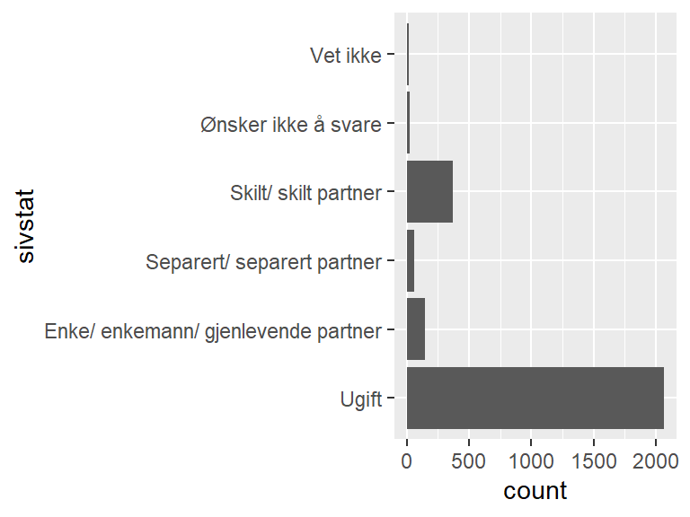

## antpers

*Antall medlemmer i husholdningen?*

| Feature | Result |
| --- | --- |
| Variable type | numeric |
| Number of missing obs. | 0 (0 %) |
| Number of unique values | 13 |
| Median | 2 |
| 1st and 3rd quartiles | 2; 4 |
| Min. and max. | 1; 98 |

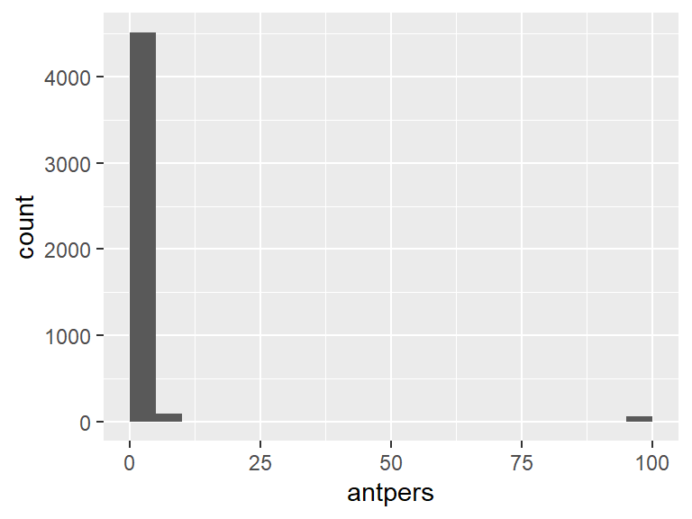

- Note that the following possible outlier values were detected: "1", "19", "98".

## antbarn1

*Antall barn under 6 år.*

| Feature | Result |
| --- | --- |
| Variable type | numeric |
| Number of missing obs. | 1135 (24.29 %) |
| Number of unique values | 7 |
| Median | 0 |
| 1st and 3rd quartiles | 0; 0 |
| Min. and max. | 0; 99 |

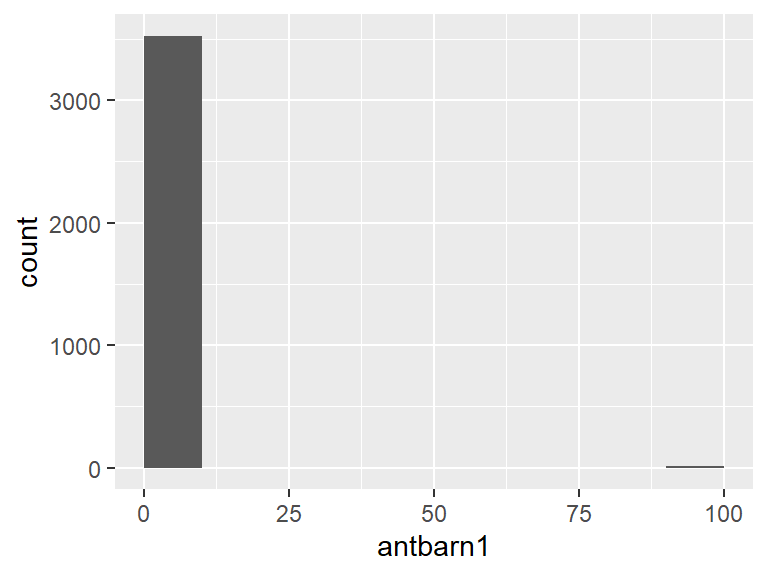

- Note that the following possible outlier values were detected: "1", "2", "3", "4", "98", "99".

## antbarn2

*Antall barn 6-18 år.*

| Feature | Result |
| --- | --- |
| Variable type | numeric |
| Number of missing obs. | 1135 (24.29 %) |
| Number of unique values | 9 |
| Median | 0 |
| 1st and 3rd quartiles | 0; 1 |
| Min. and max. | 0; 99 |

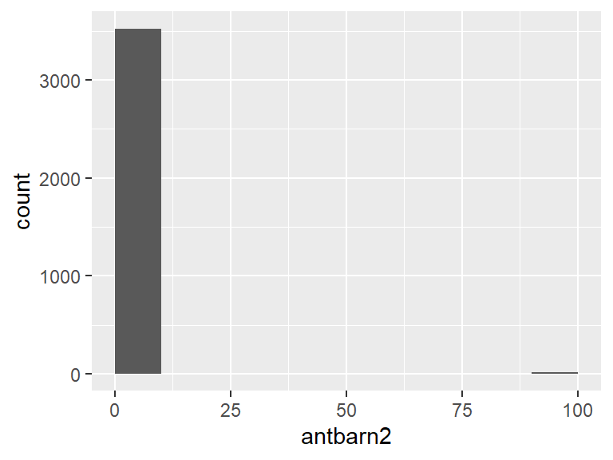

- Note that the following possible outlier values were detected: "98", "99".

## helse

*Egenopplevd helse.*

| Feature | Result |
| --- | --- |
| Variable type | haven_labelled |
| Number of missing obs. | 0 (0 %) |
| Number of unique values | 7 |
| Mode | “God” |

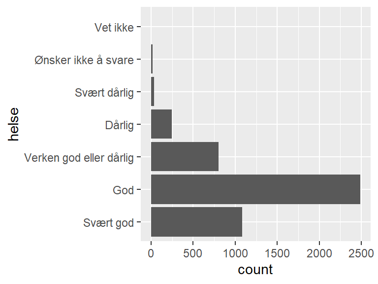

- Note that the following levels have at most five observations: "Vet ikke".

## tob1

*Hender at røyker*

| Feature | Result |
| --- | --- |
| Variable type | haven_labelled |
| Number of missing obs. | 0 (0 %) |
| Number of unique values | 4 |
| Mode | “Nei” |

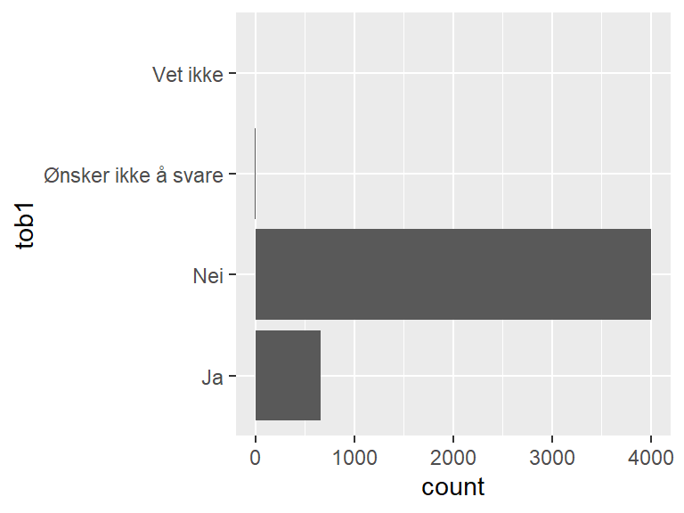

- Note that the following levels have at most five observations: "Vet ikke".

## tob2

*Røyker daglig/av og til?*

| Feature | Result |
| --- | --- |
| Variable type | haven_labelled |
| Number of missing obs. | 4009 (85.81 %) |
| Number of unique values | 3 |
| Mode | “Av og til” |

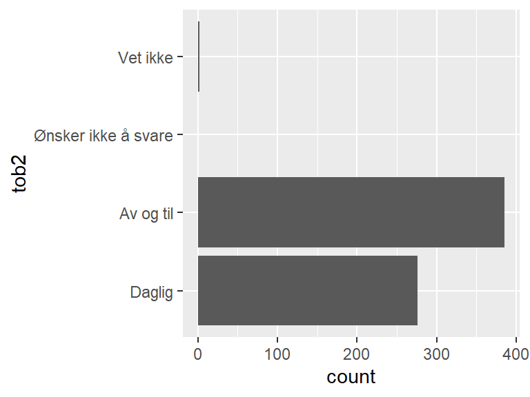

- Note that the following levels have at most five observations: "Vet ikke".

## tob3

*Røyker du sigaretter*

| Feature | Result |
| --- | --- |
| Variable type | haven_labelled |
| Number of missing obs. | 4287 (91.76 %) |
| Number of unique values | 3 |
| Mode | “Ja” |

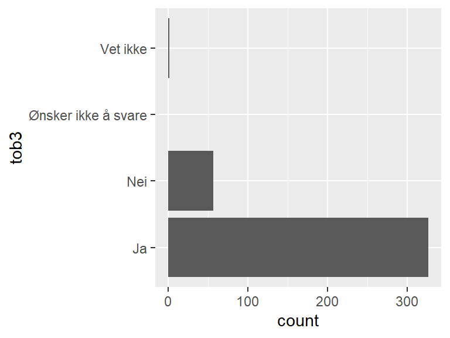

- Note that the following levels have at most five observations: "Vet ikke".

## tob4a

*Hvor mange sigaretter per uke*

| Feature | Result |
| --- | --- |
| Variable type | numeric |
| Number of missing obs. | 4346 (93.02 %) |
| Number of unique values | 20 |
| Median | 2 |
| 1st and 3rd quartiles | 1; 6 |
| Min. and max. | 1; 999 |

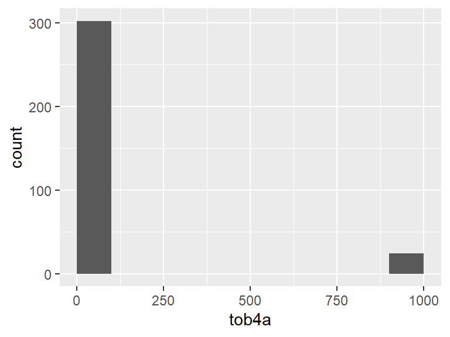

- Note that the following possible outlier values were detected: "997", "998", "999".

## tob5

*Hvor ofte røyker du sigaretter*

| Feature | Result |
| --- | --- |
| Variable type | haven_labelled |
| Number of missing obs. | 4346 (93.02 %) |
| Number of unique values | 4 |
| Mode | “Sjeldnere” |

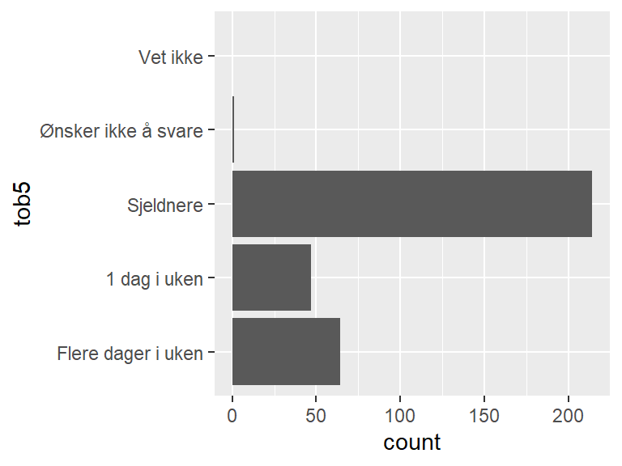

- Note that the following levels have at most five observations: "Ønsker ikke å svare".

## tob13

*Har du noen gang røykt daglig*

| Feature | Result |
| --- | --- |
| Variable type | haven_labelled |
| Number of missing obs. | 4287 (91.76 %) |
| Number of unique values | 4 |
| Mode | “Ja” |

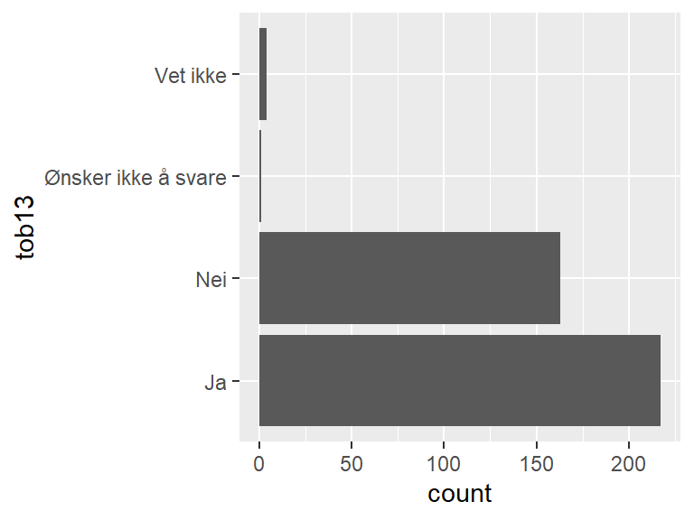

- Note that the following levels have at most five observations: "Vet ikke", "Ønsker ikke å svare".

## tob14

*Har du noen gang røykt daglig eller av og til*

| Feature | Result |
| --- | --- |
| Variable type | haven_labelled |
| Number of missing obs. | 673 (14.4 %) |
| Number of unique values | 5 |
| Mode | “Nei, aldri” |

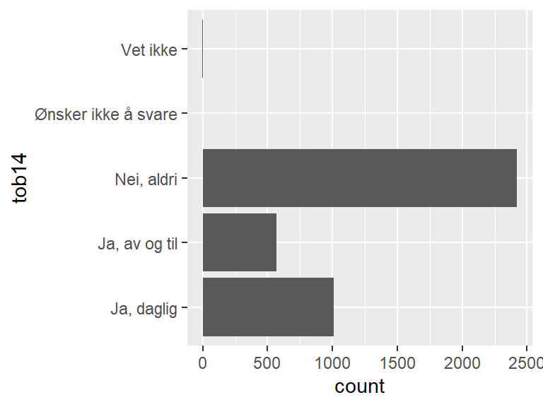

- Note that the following levels have at most five observations: "Vet ikke", "Ønsker ikke å svare".

## tob20

*I hvilket år sluttet du å røyke daglig*

| Feature | Result |
| --- | --- |
| Variable type | numeric |
| Number of missing obs. | 3447 (73.78 %) |
| Number of unique values | 61 |
| Median | 2011 |
| 1st and 3rd quartiles | 2000; 2018 |
| Min. and max. | 1966; 9999 |

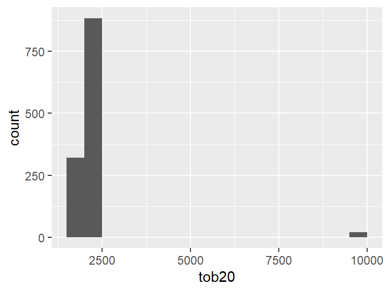

- Note that the following possible outlier values were detected: "9998", "9999".

## tob21

*Hvor mange ganger forsøkte du å slutte å røyke daglig før du lyktes*

| Feature | Result |
| --- | --- |
| Variable type | numeric |
| Number of missing obs. | 3447 (73.78 %) |
| Number of unique values | 23 |
| Median | 1 |
| 1st and 3rd quartiles | 0; 3 |
| Min. and max. | 0; 99 |

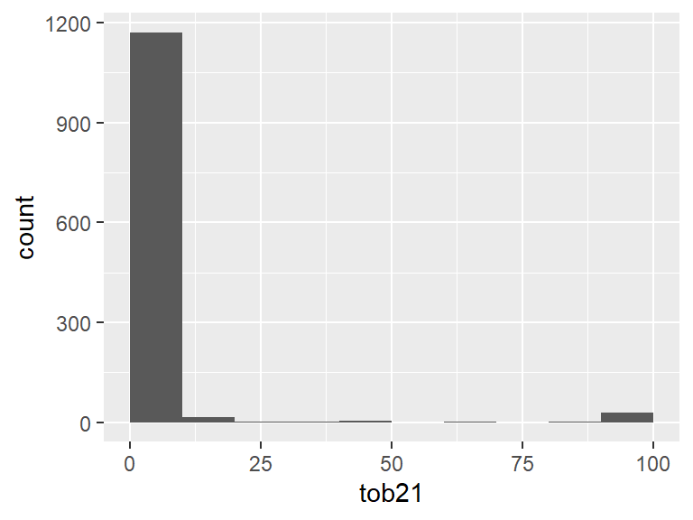

- Note that the following possible outlier values were detected: "25", "30", "40", "50", "67", "90", "98", "99".

## tob22a

*Sluttet siste gang - brukte snus*

| Feature | Result |
| --- | --- |
| Variable type | haven_labelled |
| Number of missing obs. | 4334 (92.77 %) |
| Number of unique values | 2 |
| Mode | “Nei” |

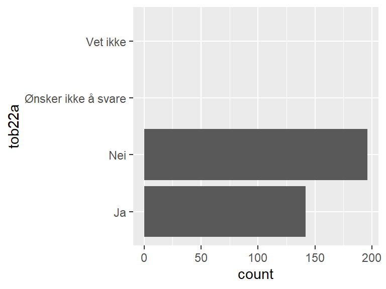

## tob22b

*Sluttet siste gang - brukte nikotinlegemiddel*

| Feature | Result |
| --- | --- |
| Variable type | haven_labelled |
| Number of missing obs. | 4334 (92.77 %) |
| Number of unique values | 2 |
| Mode | “Nei” |

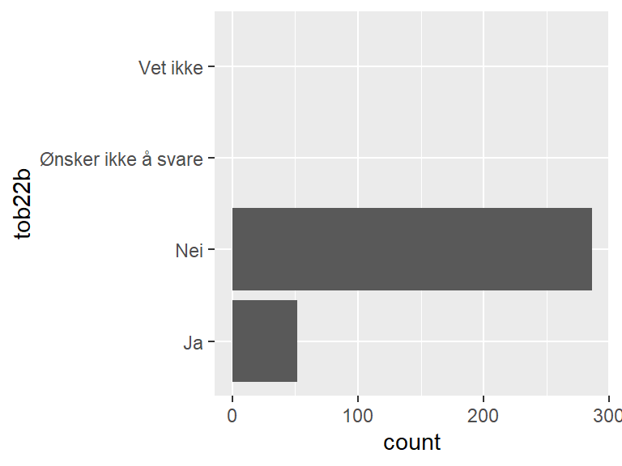

## tob22d

*Sluttet siste gang - brukte røykeavvenningsprodukt*

| Feature | Result |
| --- | --- |
| Variable type | haven_labelled |
| Number of missing obs. | 4334 (92.77 %) |
| Number of unique values | 2 |
| Mode | “Nei” |

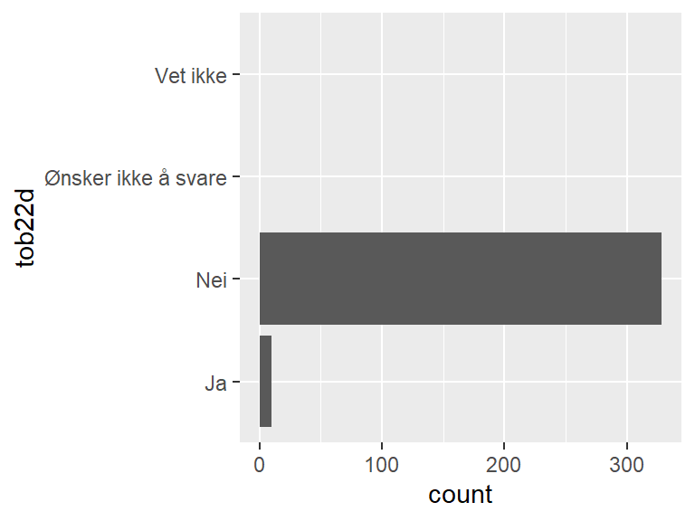

## tob22q

*Sluttet siste gang - søkte helsetjenesten*

| Feature | Result |
| --- | --- |
| Variable type | haven_labelled |
| Number of missing obs. | 4334 (92.77 %) |
| Number of unique values | 2 |
| Mode | “Nei” |

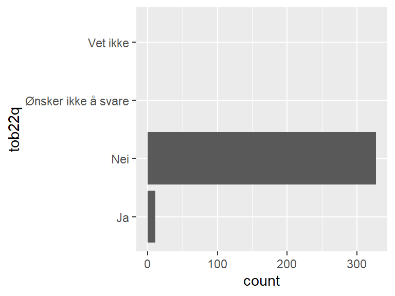

## tob22s

*Sluttet siste gang - brukte e-sigaretter*

| Feature | Result |
| --- | --- |
| Variable type | haven_labelled |
| Number of missing obs. | 4334 (92.77 %) |
| Number of unique values | 2 |
| Mode | “Nei” |

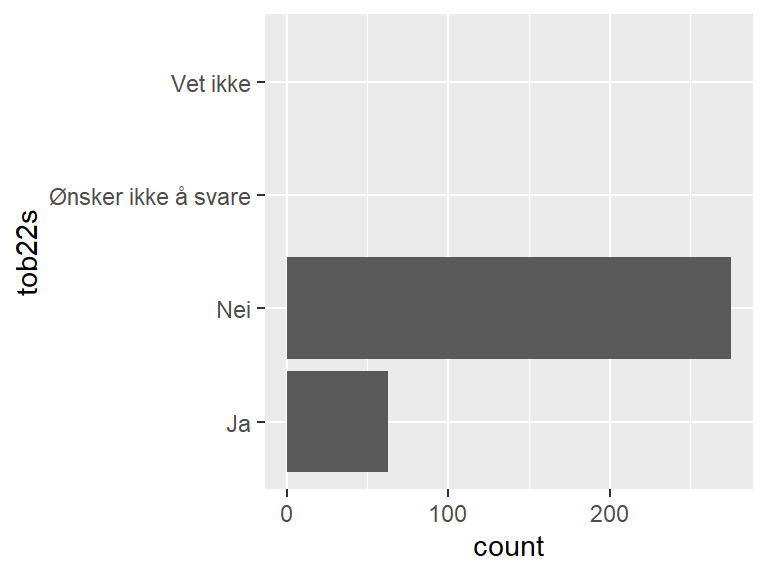

## tob22r

*Sluttet siste gang - søkte nettsider eller mobiltjenester for røykeslutt*

| Feature | Result |
| --- | --- |
| Variable type | haven_labelled |
| Number of missing obs. | 4334 (92.77 %) |
| Number of unique values | 2 |
| Mode | “Nei” |

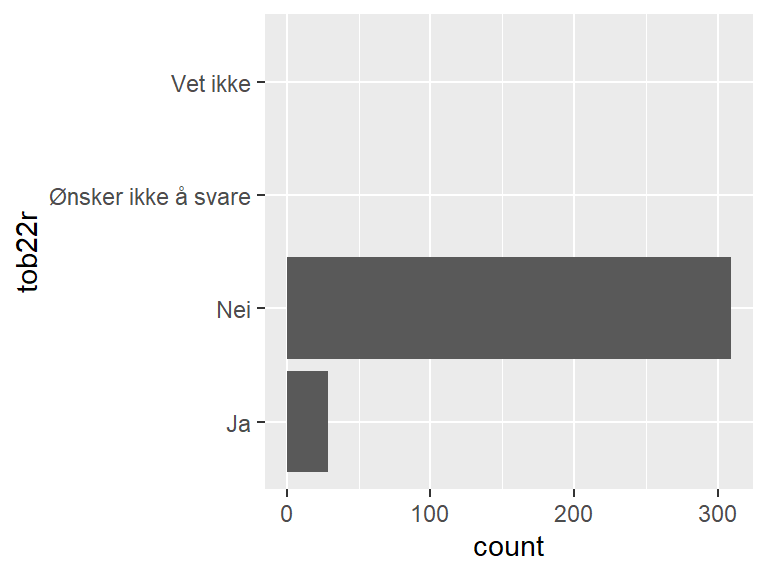

## tob23

*Hvor gammel var du da du begynte å røyke daglig*

| Feature | Result |
| --- | --- |
| Variable type | numeric |
| Number of missing obs. | 3171 (67.87 %) |
| Number of unique values | 40 |
| Median | 17 |
| 1st and 3rd quartiles | 15; 19 |
| Min. and max. | 8; 99 |

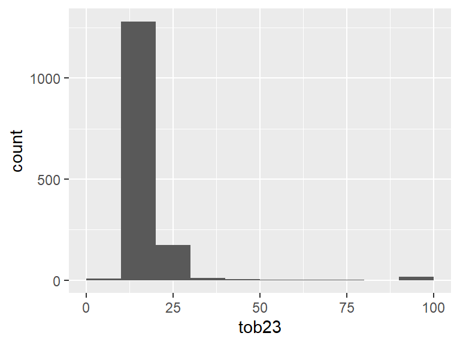

- Note that the following possible outlier values were detected: "8", "26", "27", "28", "29", "30", "31", "32", "35", "36", "37", "38", "40", "42", "45", "46", "50", "54", "66", "67", "78", "98", "99".

## tob30

*Røyker du sigaretter daglig*

| Feature | Result |
| --- | --- |
| Variable type | haven_labelled |
| Number of missing obs. | 4396 (94.09 %) |
| Number of unique values | 2 |
| Mode | “Ja” |

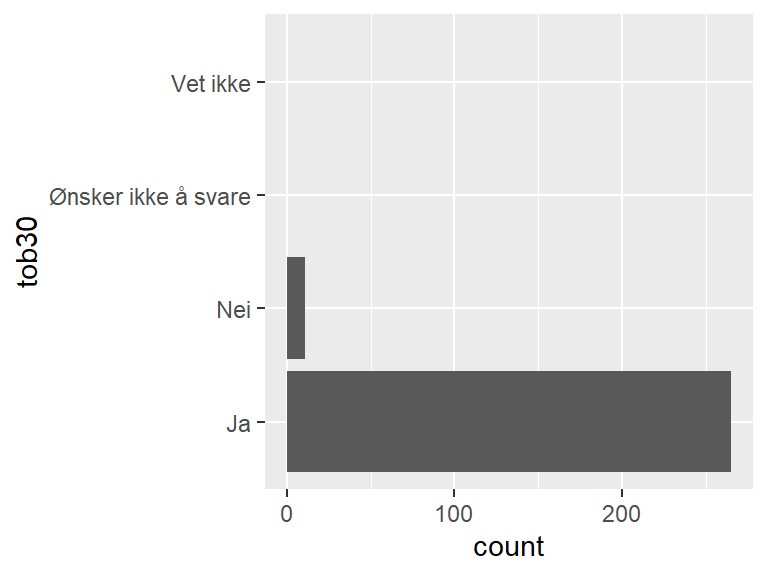

## tob31a

*Hvor mange sigaretter røyker du gjennomsnittlig pr. dag*

| Feature | Result |
| --- | --- |
| Variable type | numeric |
| Number of missing obs. | 4407 (94.33 %) |
| Number of unique values | 22 |
| Median | 10 |
| 1st and 3rd quartiles | 6; 15 |
| Min. and max. | 1; 999 |

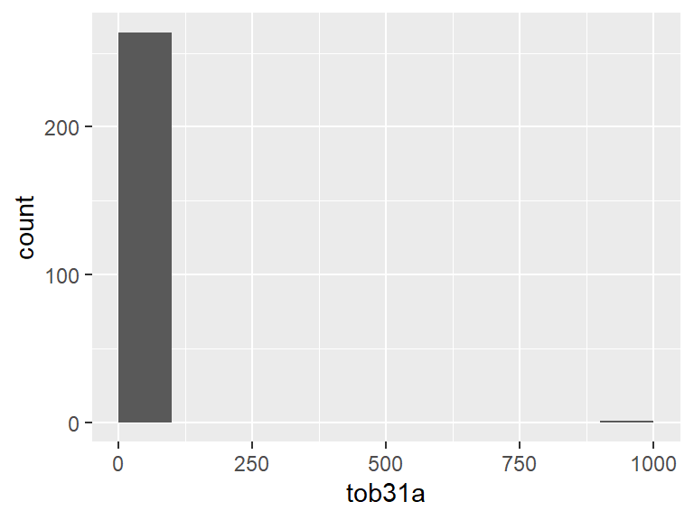

- The following suspected missing value codes enter as regular values: "999".
- Note that the following possible outlier values were detected: "999".

## tob31b

*Hvor mange av disse sigarettene er fabrikklagde*

| Feature | Result |
| --- | --- |
| Variable type | numeric |
| Number of missing obs. | 4407 (94.33 %) |
| Number of unique values | 25 |
| Median | 8 |
| 1st and 3rd quartiles | 3; 12 |
| Min. and max. | 0; 999 |

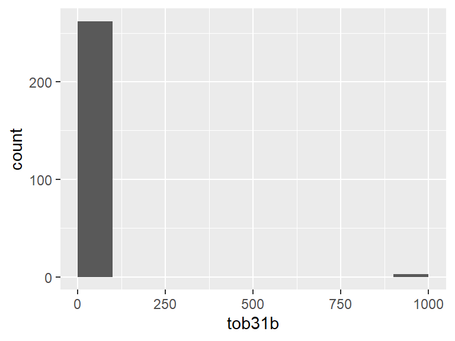

- Note that the following possible outlier values were detected: "30", "998", "999".

## tob31c

*Hvor mange av disse sigarettene er hjemmerullede*

| Feature | Result |
| --- | --- |
| Variable type | numeric |
| Number of missing obs. | 4407 (94.33 %) |
| Number of unique values | 17 |
| Median | 0 |
| 1st and 3rd quartiles | 0; 0 |
| Min. and max. | 0; 999 |

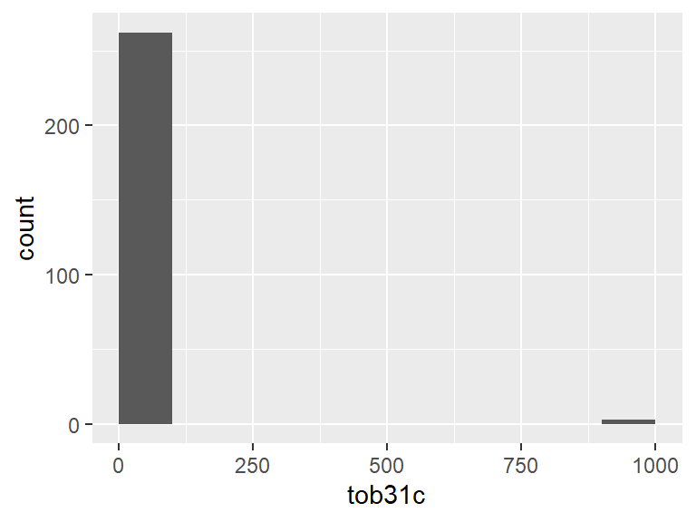

- The following suspected missing value codes enter as regular values: "999".
- Note that the following possible outlier values were detected: "1", "2", "3", "4", "5", "6", "7", "8", "9", "10", "12", "15", "17", "20", "25", "999".

## tob33

*Røyker du sigarer eller sigarillos daglig, av og til eller aldri*

| Feature | Result |
| --- | --- |
| Variable type | haven_labelled |
| Number of missing obs. | 4009 (85.81 %) |
| Number of unique values | 4 |
| Mode | “Aldri” |

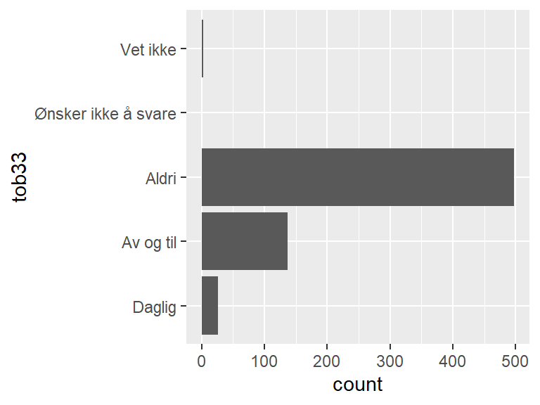

- Note that the following levels have at most five observations: "Vet ikke".

## tob34

*Hvor ofte røyker du pipe*

| Feature | Result |
| --- | --- |
| Variable type | haven_labelled |
| Number of missing obs. | 4009 (85.81 %) |
| Number of unique values | 3 |
| Mode | “Aldri” |

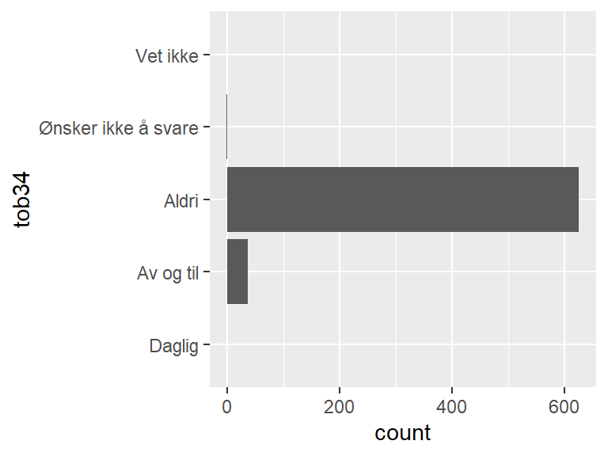

- Note that the following levels have at most five observations: "Ønsker ikke å svare".

## tob38

*Har du noen gang prøvd å slutte å røyke daglig*

| Feature | Result |
| --- | --- |
| Variable type | haven_labelled |
| Number of missing obs. | 4396 (94.09 %) |
| Number of unique values | 4 |
| Mode | “Ja” |

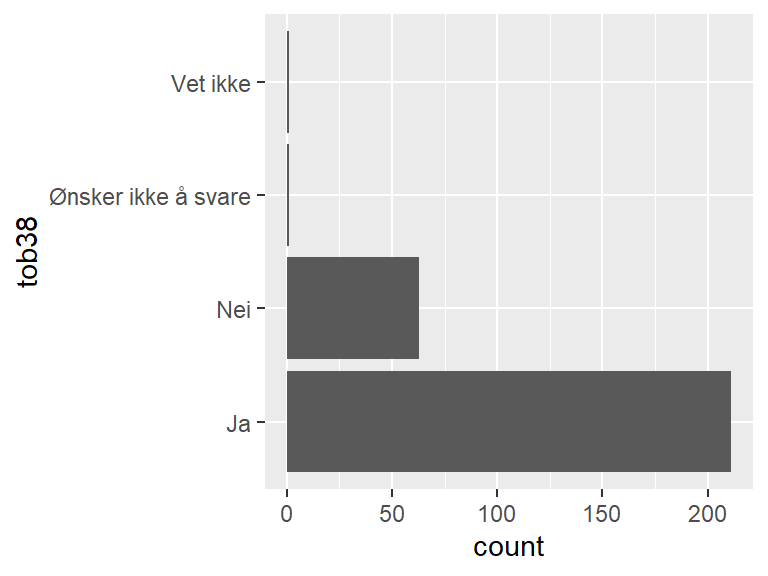

- Note that the following levels have at most five observations: "Vet ikke", "Ønsker ikke å svare".

## tob39

*Hvor mange ganger totalt har du prøvd å slutte å røyke daglig*

| Feature | Result |
| --- | --- |
| Variable type | numeric |
| Number of missing obs. | 4461 (95.48 %) |
| Number of unique values | 17 |
| Median | 3 |
| 1st and 3rd quartiles | 2; 5 |
| Min. and max. | 1; 99 |

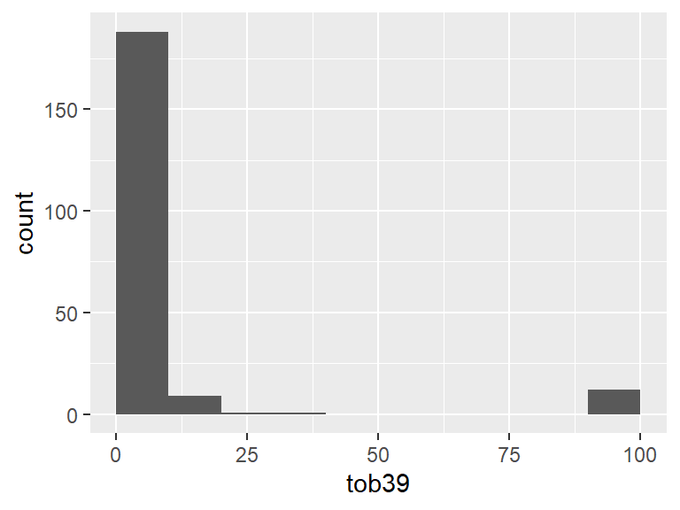

- Note that the following possible outlier values were detected: "20", "25", "40", "98", "99".

## tob40

*Har du prøvd å slutte å røyke daglig i løpet av de siste 12 månedene*

| Feature | Result |
| --- | --- |
| Variable type | haven_labelled |
| Number of missing obs. | 4461 (95.48 %) |
| Number of unique values | 2 |
| Mode | “Nei” |

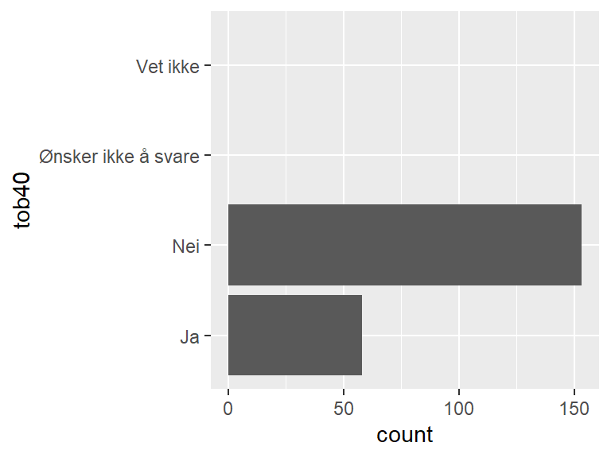

## tob42a

*Forsøkte å slutte siste gang … brukte snus*

| Feature | Result |
| --- | --- |
| Variable type | haven_labelled |
| Number of missing obs. | 4461 (95.48 %) |
| Number of unique values | 2 |
| Mode | “Nei” |

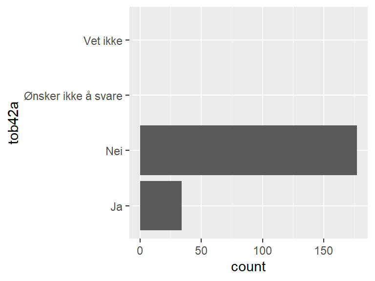

## tob42b

*Forsøkte å slutte siste gang … brukte nikotinlegemiddel*

| Feature | Result |
| --- | --- |
| Variable type | haven_labelled |
| Number of missing obs. | 4461 (95.48 %) |
| Number of unique values | 2 |
| Mode | “Nei” |

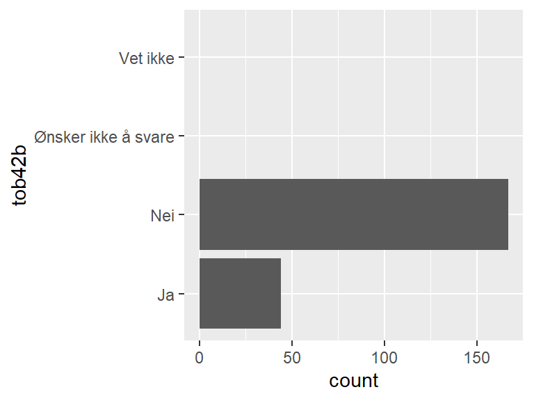

## tob42d

*Forsøkte å slutte siste gang … brukte reseptbelagt røykeavvenningsprodukt*

| Feature | Result |
| --- | --- |
| Variable type | haven_labelled |
| Number of missing obs. | 4461 (95.48 %) |
| Number of unique values | 4 |
| Mode | “Nei” |

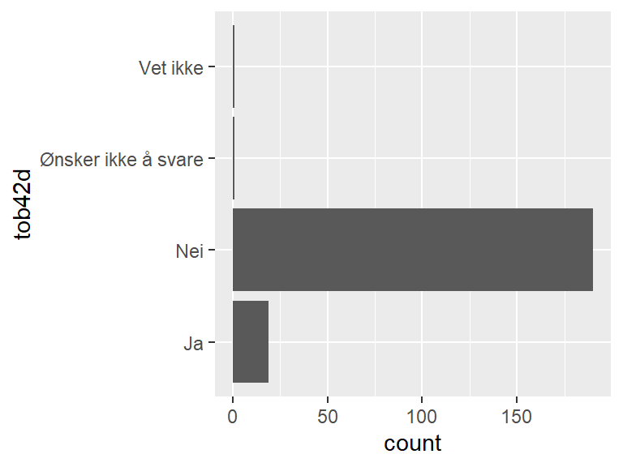

- Note that the following levels have at most five observations: "Vet ikke", "Ønsker ikke å svare".

## tob42o

*Forsøkte å slutte siste gang … brukte elektroniske sigaretter*

| Feature | Result |
| --- | --- |
| Variable type | haven_labelled |
| Number of missing obs. | 4461 (95.48 %) |
| Number of unique values | 3 |
| Mode | “Nei” |

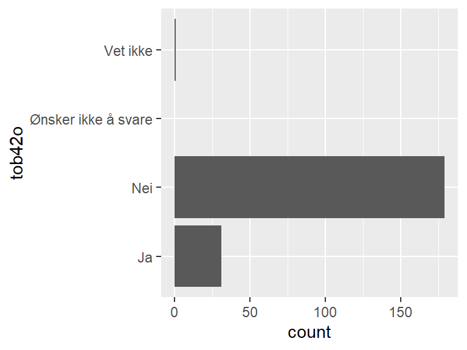

- Note that the following levels have at most five observations: "Vet ikke".

## tob42m

*Forsøkte å slutte siste gang … søkte hjelp i helsetjenesten/kommunen*

| Feature | Result |
| --- | --- |
| Variable type | haven_labelled |
| Number of missing obs. | 4461 (95.48 %) |
| Number of unique values | 2 |
| Mode | “Nei” |

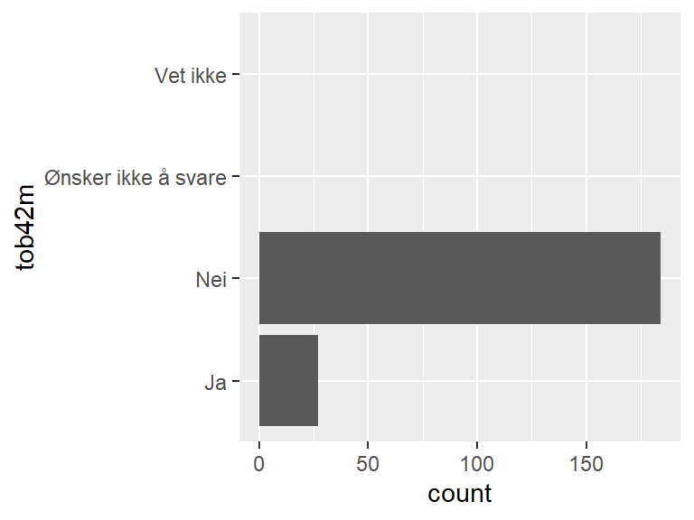

## tob42n

*Forsøkte å slutte siste gang … søkte hjelp på nettsider eller mobiltjenester for røykeslutt*

| Feature | Result |
| --- | --- |
| Variable type | haven_labelled |
| Number of missing obs. | 4461 (95.48 %) |
| Number of unique values | 2 |
| Mode | “Nei” |

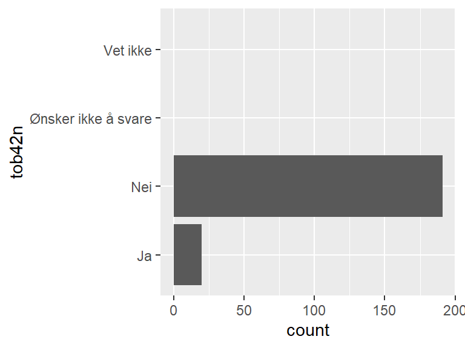

## tob43

*Vurderer du seriøst å slutte å røyke de neste 6 månedene?*

| Feature | Result |
| --- | --- |
| Variable type | haven_labelled |
| Number of missing obs. | 4009 (85.81 %) |
| Number of unique values | 4 |
| Mode | “Nei” |

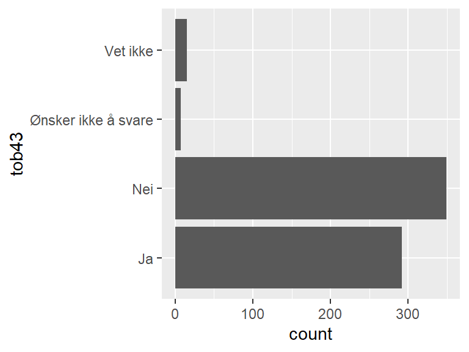

## tob44

*Planlegger du å slutte å røyke i løpet av de neste 30 dagene?*

| Feature | Result |
| --- | --- |
| Variable type | haven_labelled |
| Number of missing obs. | 4380 (93.75 %) |
| Number of unique values | 3 |
| Mode | “Nei” |

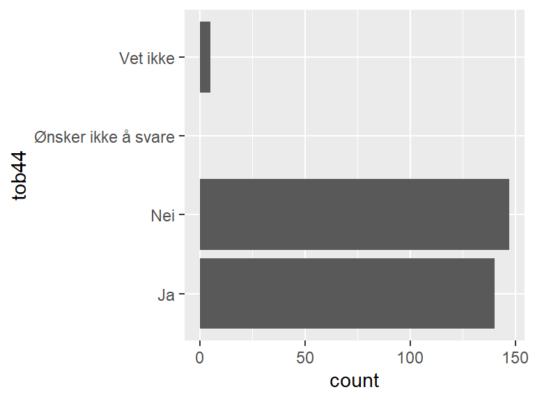

- Note that the following levels have at most five observations: "Vet ikke".

## tobvan1

*Hvor lang tid etter at du våkner, tenner du din første sigarett*

| Feature | Result |
| --- | --- |
| Variable type | haven_labelled |
| Number of missing obs. | 4396 (94.09 %) |
| Number of unique values | 5 |
| Mode | “Mellom 6 - 30 minutter” |

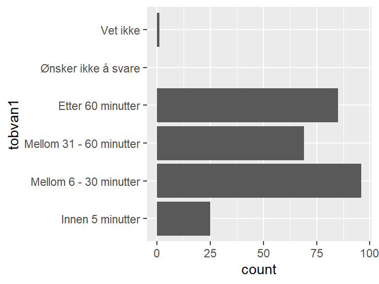

- Note that the following levels have at most five observations: "Vet ikke".

## tobe

*Hvor ofte bruker du vape/e-sigaretter/fordampere*

| Feature | Result |
| --- | --- |
| Variable type | haven_labelled |
| Number of missing obs. | 0 (0 %) |
| Number of unique values | 5 |
| Mode | “Aldri” |

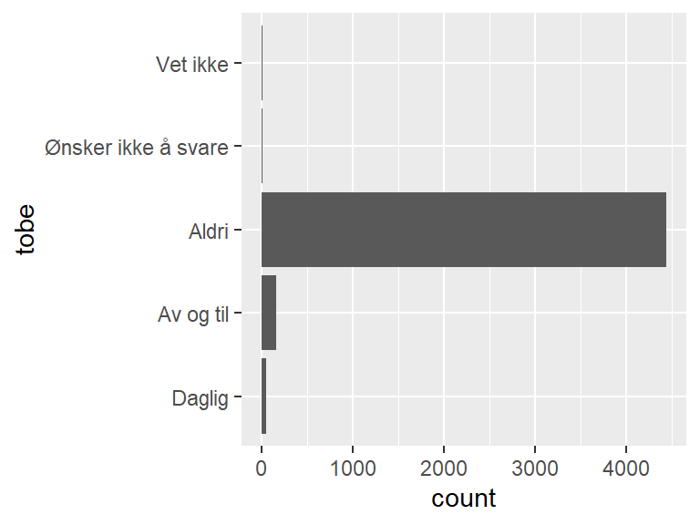